# extendedCosinorVignette

```r
library(extendedCosinor)
library(tidyverse)
library(cluster)
```

## Data Requirements

We’ll simulate seven days of minute-level data `x` for one person for this demonstration. `cosinorExtendedModel` and `cosinorBasicModel` both take a vector of epoch-level data as input, as well as the argument `window` which specifies the epoch duration in minutes. The vector must have a length that is an integer multiple of `1440/window`. The model assumes the first element of x corresponds to the first epoch after midnight.

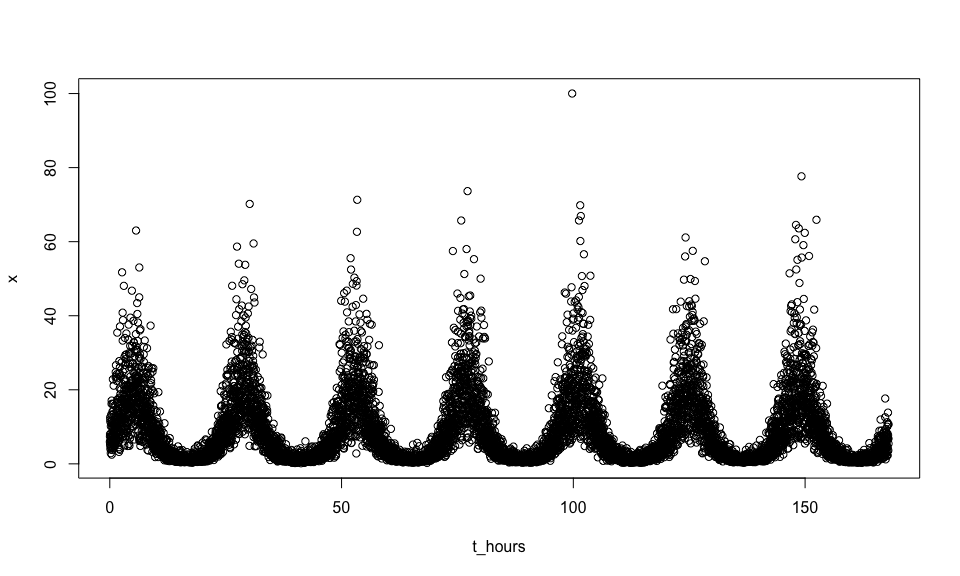

```r
t_hours <- seq(0, 24*7,by = 1/60)[-1]
x <- sqrt(exp(2 + 3*cos((t_hours- 5)/24*2*pi) + rnorm(length(t_hours),1)))
plot(x~t_hours)
```

```r
cosOut <- cosinorExtendedModel(
    x = x,
    window = 1,
    export_ts = TRUE,
    export_cosinor_param = TRUE,
    export_nls_outcome = TRUE
)
cosOut$estimates
```

```
#>     mu_ext gamma_ext alpha_ext beta_ext  phi_ext ndays acrotime_ext maximum_ext
#> 1 1.030317  42.32936 0.9999975 2.373051 4.976125     7     4.976125    22.19506
#>   minimum_ext amplitude_ext mesor_ext hours_above_mesor_ext midpoint_ext
#> 1    1.394804      20.80025   8.32566              9.366667     11.79493
#>   hours_above_midpoint_ext up_mesor_ext down_mesor_ext up_mesor_deriv_ext
#> 1                 7.583333    0.2927915       9.659458           3.530847
#>    rss_ext  tss_y F_pseudo_ext    R2_ext mesor_cos  phi_cos  gam_cos
#> 1 337906.8 901070     939.8613 0.6249938  8.325658 4.975201 9.961423
#>   amplitude_cos  rss_cos    R2_cos niter info
#> 1      19.92285 400951.1 0.5550278    44    1
#>                                                   message
#> 1 Relative error in the sum of squares is at most `ftol'.
```

```r
cosOut$cosinor_ts
```

```
#> # A tibble: 10,080 × 4
#>    time_across_days     y y_cos y_ext
#>               <dbl> <dbl> <dbl> <dbl>
#>  1           0.0167  5.95  11.0  7.38
#>  2           0.0333  7.42  11.0  7.43
#>  3           0.05    8.05  11.1  7.49
#>  4           0.0667  5.26  11.1  7.54
#>  5           0.0833 12.5   11.2  7.60
#>  6           0.1     6.22  11.2  7.65
#>  7           0.117  11.4   11.3  7.71
#>  8           0.133  12.0   11.3  7.76
#>  9           0.15    4.78  11.3  7.82
#> 10           0.167   4.17  11.4  7.88
#> # ℹ 10,070 more rows
```

## Interpreting the Output

### Primary Model Parameter Estimates

The five primary model parameter estimates are the following:

```r
cosOut$estimates %>% select(mu_ext:phi_ext)
```

```
#>     mu_ext gamma_ext alpha_ext beta_ext  phi_ext
#> 1 1.030317  42.32936 0.9999975 2.373051 4.976125
```

These correspond to the model outlined by Marler et al (2006). We’ve renamed some of the parameters ($\mu_ext$ was “min” and $\gamma_ext$ was “amp”) from the original version to avoid confusion with the amplitude and minimum of the fitted function.

$$y(t) = \mu_{\mathrm{ext}} + \gamma_{\mathrm{ext}}\cdot
\mathrm{expit}\bigg(\beta_{\mathrm{ext}} \Big(\cos(\left[t -
\phi_{\mathrm{ext}}\right]\cdot 2\pi/24)-\alpha_{\mathrm{ext}} \Big)
\bigg) + \epsilon(t)$$

The plot below shows that $mu_ext$ (formerly “min”) can be close to the function minumum, but it is not exact. Additionally, $gam_ext$ (formerly “amp”) influences the function amplitude, but it is not the amplitude of the fitted function.

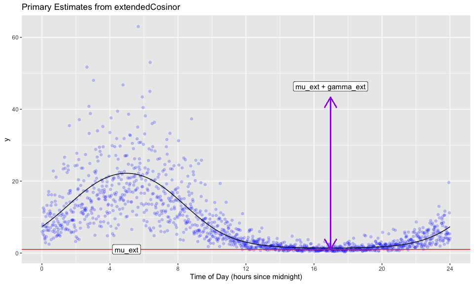

```r
cosOut$cosinor_ts %>% filter(
    time_across_days <= 24
) %>% ggplot() + geom_point(
    aes(
        x = time_across_days, y = y
    ), alpha = 0.2, color = "blue"
)  + geom_line(
    aes(
        x = time_across_days, y = y_ext
    )
) + scale_x_continuous(
    "Time of Day (hours since midnight)",
    breaks = 4*(0:6)
) + geom_hline(
    "hline",
    yintercept = c(
        cosOut$estimates$mu_ext
    ), color = "red"
) + geom_segment(
    aes(
        xend = cosOut$estimates$acrotime_ext+12,
        x = cosOut$estimates$acrotime_ext+12,
        y = cosOut$estimates$mu_ext,
        yend = cosOut$estimates$mu_ext +
            cosOut$estimates$gamma_ext
    ), color = "purple", arrow = arrow(ends = "both")
) + geom_label(
    data = tibble(
        name = c("mu_ext", "mu_ext + gamma_ext"),
        x = c(cosOut$estimates$acrotime_ext, cosOut$estimates$acrotime_ext + 12),
        y = c(
            cosOut$estimates$mu_ext,
            cosOut$estimates$mu_ext + cosOut$estimates$gamma_ext + 3
        )
    ),
    aes(
        x = x,
        y = y,
        label = name
    )
) + ggtitle(
    "Primary Estimates from extendedCosinor"
)
```

### Secondary Estimates

Secondary estimates are more appropriate for analysis, and are derived from the fitted function and residuals.

```r
cosOut$estimates %>% select(acrotime_ext:up_mesor_deriv_ext,F_pseudo_ext,R2_ext)
```

```
#>   acrotime_ext maximum_ext minimum_ext amplitude_ext mesor_ext
#> 1     4.976125    22.19506    1.394804      20.80025   8.32566
#>   hours_above_mesor_ext midpoint_ext hours_above_midpoint_ext up_mesor_ext
#> 1              9.366667     11.79493                 7.583333    0.2927915
#>   down_mesor_ext up_mesor_deriv_ext F_pseudo_ext    R2_ext
#> 1       9.659458           3.530847     939.8613 0.6249938
```

The connection of each estimate to the fitted function is depicted below.

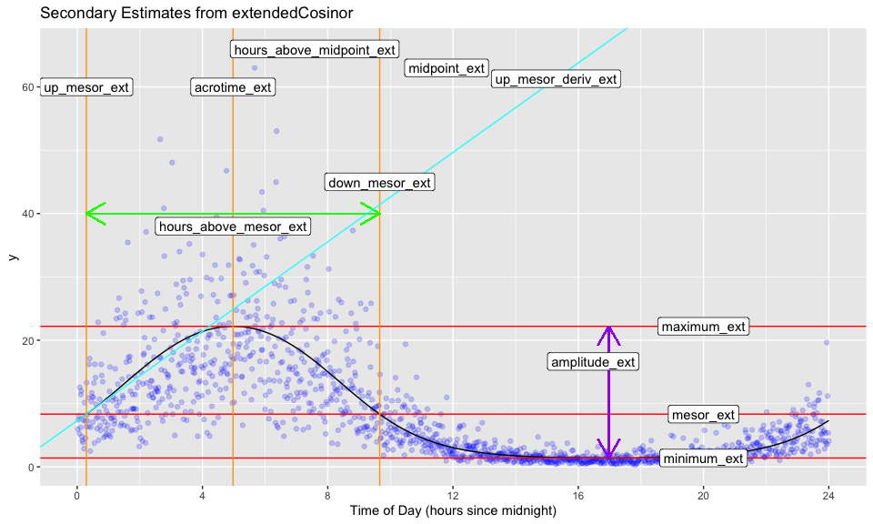

```r
label.df = cosOut$estimates %>% select(
    acrotime_ext:up_mesor_deriv_ext
) %>% pivot_longer(
    acrotime_ext:up_mesor_deriv_ext
) %>% mutate(
    x = ifelse(
        name %in% c(
            "minimum_ext",
            "mesor_ext",
            "maximum_ext"
        ), 20, value
    ),
    y = ifelse(
        !name %in% c(
            "minimum_ext",
            "mesor_ext",
            "maximum_ext"
        ), 60 + c(0,-15,3, 6), value
    ),
    y = ifelse(
        name == "amplitude_ext",
        cosOut$estimates$maximum_ext*0.75,
        y
    ),
    x = ifelse(
        name == "amplitude_ext",
        cosOut$estimates$acrotime_ext+11.5,
        x
    ),
    y = ifelse(
        name == "hours_above_mesor_ext",
        38,
        y
    ),
    x = ifelse(
        name == "hours_above_mesor_ext",
        cosOut$estimates$acrotime_ext,
        x
    ),
    y = ifelse(
        name == "up_mesor_deriv_ext",
        cosOut$estimates$mesor_ext + (15*cosOut$estimates$up_mesor_deriv_ext),
        y
    ),
    x = ifelse(
        name == "up_mesor_deriv_ext",
        cosOut$estimates$up_mesor_ext + 15,
        x
    )
)

cosOut$cosinor_ts %>% filter(
    time_across_days <= 24
) %>% ggplot() + geom_point(
    aes(
        x = time_across_days, y = y
    ), alpha = 0.2, color = "blue"
)  + geom_line(
    aes(
        x = time_across_days, y = y_ext
    )
) + scale_x_continuous(
    "Time of Day (hours since midnight)",
    breaks = 4*(0:6)
) + geom_hline(
    "hline",
    yintercept = c(
        cosOut$estimates$minimum_ext,
        cosOut$estimates$mesor_ext,
        cosOut$estimates$maximum_ext
    ), color = "red"
) + geom_vline(
    xintercept = c(
        cosOut$estimates$up_mesor_ext,
        cosOut$estimates$down_mesor_ext,
        cosOut$estimates$acrotime_ext
    ), color = "orange"
) + geom_segment(
    aes(
        xend = cosOut$estimates$down_mesor_ext,
        x = cosOut$estimates$up_mesor_ext,
        y = 40, yend = 40
    ), color = "green", arrow = arrow(ends = "both")
) + geom_segment(
    aes(
        xend = cosOut$estimates$acrotime_ext+12,
        x = cosOut$estimates$acrotime_ext+12,
        y = cosOut$estimates$minimum_ext,
        yend = cosOut$estimates$minimum_ext +
            cosOut$estimates$amplitude_ext
    ), color = "purple", arrow = arrow(ends = "both")
) + geom_abline(
    aes(
        intercept = cosOut$estimates$mesor_ext -
            cosOut$estimates$up_mesor_deriv_ext*
            cosOut$estimates$up_mesor_ext,
        slope = cosOut$estimates$up_mesor_deriv_ext
    ), color = "cyan"
) + geom_label(
    data = label.df,
    aes(
        x = x,
        y = y,
        label = name
    )
) + ggtitle(
    "Secondary Estimates from extendedCosinor"
)
```

### Comparison to ActCR::ActExtendCosinor

```r
actcrOut <- ActCR::ActExtendCosinor(
    x = x,
    window = 1,
    export_ts = TRUE
)
actcrOut$params %>% as.data.frame
```

```
#>    minimum      amp alpha     beta acrotime F_pseudo  UpMesor DownMesor
#> 1 1.030317 42.32948     1 2.373049 4.976124 939.8614 4.976124  4.976124
#>      MESOR ndays
#> 1 22.19506     7
```

The plot below shows how certain estimates from the `ActCR::ActExtendCosinor` output map to the fitted function. The plot below confirms that the estimates labelled `amp` and `minimum` do not correspond to the amplitude and minimum of the fitted function. Additionally, the estimate of `MESOR`, `UpMesor`, and `DownMesor` do not seem to capture the intended construct–the midline of rhythm.

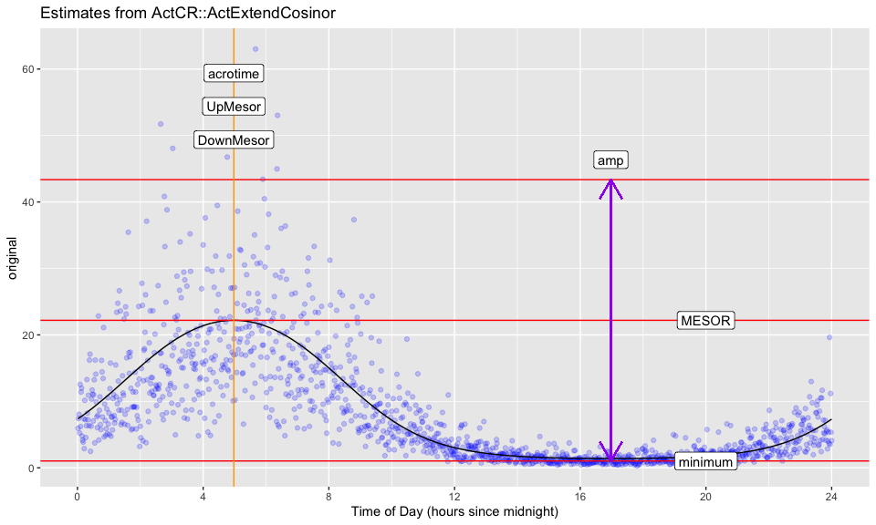

```r
actcrOut$cosinor_ts %>% filter(
    time_across_days <= 24
) %>% ggplot() + geom_point(
    aes(
        x = time_across_days, y = original
    ), alpha = 0.2, color = "blue"
)  + geom_line(
    aes(
        x = time_across_days, y = fittedYext
    )
) + scale_x_continuous(
    "Time of Day (hours since midnight)",
    breaks = 4*(0:6)
) + geom_hline(
    "hline",
    yintercept = c(
        actcrOut$params$minimum,
        actcrOut$params$MESOR,
        actcrOut$params$minimum + actcrOut$params$amp
    ), color = "red"
) + geom_vline(
    xintercept = c(
        actcrOut$params$acrotime,
        actcrOut$params$UpMesor,
        actcrOut$params$DownMesor
    ), color = "orange"
) + geom_segment(
    aes(
        xend = actcrOut$params$acrotime + 12,
        x = actcrOut$params$acrotime + 12,
        y = actcrOut$params$minimum,
        yend = actcrOut$params$minimum + actcrOut$params$amp
    ), color = "purple", arrow = arrow(ends = "both")
)  + geom_label(
    data = tibble(
        name = c("minimum", "amp", "acrotime", "MESOR", "UpMesor", "DownMesor"),
        x = c(
            20, actcrOut$params$acrotime + 12, actcrOut$params$acrotime,
            20, actcrOut$params$UpMesor, actcrOut$params$DownMesor
        ),
        y = c(
            actcrOut$params$minimum,
            actcrOut$params$minimum + actcrOut$params$amp + 3,
            actcrOut$params$MESOR*2 + 15,
            actcrOut$params$MESOR,
            actcrOut$params$MESOR*2+10,
            actcrOut$params$MESOR*2 + 5
        )
    ),
    aes(
        x = x,
        y = y,
        label = name
    )
) + ggtitle(
    "Estimates from ActCR::ActExtendCosinor"
)
```

### Cosinor Model Estimates

By setting the option `export_cosinor_param = TRUE`, the function includes basic cosinor parameter estimates in the output. These estimates are mapped onto the basic cosinor fit below.

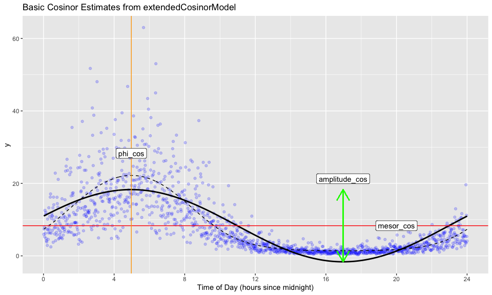

```r
cosOut$cosinor_ts %>% filter(
    time_across_days <= 24
) %>% ggplot() + geom_point(
    aes(
        x = time_across_days, y = y
    ), alpha = 0.2, color = "blue"
)  + geom_line(
    aes(
        x = time_across_days, y = y_ext
    ), linetype = 2
) + geom_line(
    aes(
        x = time_across_days, y = y_cos
    ), linewidth = 1
) + scale_x_continuous(
    "Time of Day (hours since midnight)",
    breaks = 4*(0:6)
) + geom_hline(
    "hline",
    yintercept = cosOut$estimates$mesor_cos, color = "red"
) + geom_vline(
    xintercept = cosOut$estimates$phi_cos, color = "orange"
) + geom_segment(
    aes(
        yend = cosOut$estimates$mesor_cos - 0.5*cosOut$estimates$amplitude_cos,
        y = cosOut$estimates$mesor_cos + 0.5*cosOut$estimates$amplitude_cos,
        x = cosOut$estimates$phi_cos + 12,
        yend = cosOut$estimates$phi_cos + 12
    ), color = "green", arrow = arrow(ends = "both")
) + geom_label(
    data = tibble(
        name = c("mesor_cos", "amplitude_cos", "phi_cos"),
        x = c(
            20,
            cosOut$estimates$phi_cos + 12,
            cosOut$estimates$phi_cos
        ),
        y = c(
            cosOut$estimates$mesor_cos,
            cosOut$estimates$mesor_cos + 0.5*cosOut$estimates$amplitude_cos + 3,
            cosOut$estimates$mesor_cos + 0.5*cosOut$estimates$amplitude_cos + 10
        )
    ),
    aes(
        x = x,
        y = y,
        label = name
    )
) + ggtitle(
    "Basic Cosinor Estimates from extendedCosinorModel"
)
```

### Comparing Basic and Extended Cosinor Model Estimates

The figure above shows that the extended cosinor model (dashed line) appears to fit the observed data better than the basic cosinor model (solid line). The estimates of the fitted amplitude, acrotime, and mesor can be compared between both models.

```r
cosOut$estimates %>% transmute(
    amplitude_ext, amplitude_cos,
    acrotime_ext, phi_cos,
    mesor_ext, mesor_cos
)
```

```
#>   amplitude_ext amplitude_cos acrotime_ext  phi_cos mesor_ext mesor_cos
#> 1      20.80025      19.92285     4.976125 4.975201   8.32566  8.325658
```

The pseudo F-statistic indicates the degree to which the extended cosinor model fits the data better than the basic cosinor model. `R2_ext` tells us that 62.5% of the variation in the epoch level data can be predicted by the extended cosinor fit. `R2_cos` tells us that 55.5% of the variation in the epoch level data can be predicted by the basic cosinor fit.

```r
cosOut$estimates %>% select(
    F_pseudo_ext, R2_ext, R2_cos
)
```

```
#>   F_pseudo_ext    R2_ext    R2_cos
#> 1     939.8613 0.6249938 0.5550278
```